# Practical 4: Deep Learning

Nina van Gerwen (1860852)

2022-12-08

## 2: Take-home Exercises: a DFF NN

Here we will develop a *deep feed-forward* neural network! Fun times await.

### 2.1: Data preparation

First, we prepare the data and load the proper packages.

```r
library(tidyverse)
library(keras)
```

#### 2.1.1: Loading the MNIST dataset

```r
mnist <- dataset_mnist()
```

```
## Loaded Tensorflow version 2.10.0
```

#### 2.1.2: Creating a plotting function and creating an image

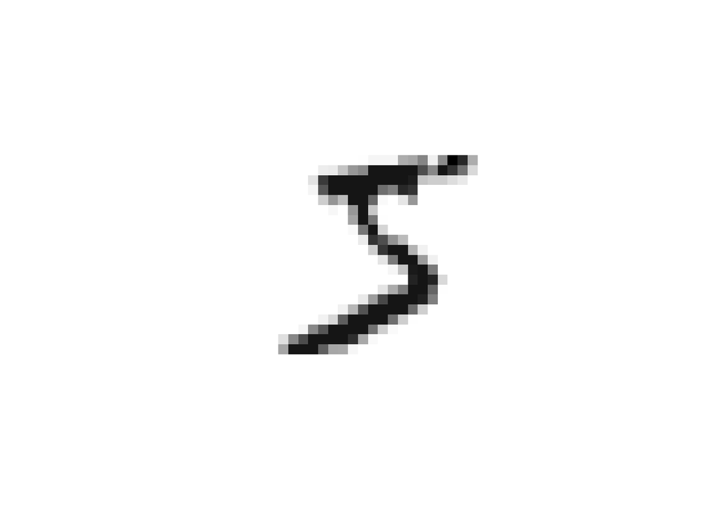

```r
plot_img <- function(img, col = gray.colors(255, start = 1, end = 0), ...) {
  image(t(img), asp = 1, ylim = c(1.1, -0.1), col = col, bty = "n", axes = FALSE, ...)
}

plot_img(mnist$train$x[1,,])
```

Code was taken from the practical.

#### 2.1.3: Ensuring brightness values of the images are in the range (0, 1)

```r
range(mnist$train$x)
```

```
## [1]   0 255
```

```r
mnist$train$x <- mnist$train$x / 255
range(mnist$train$x)
```

```
## [1] 0 1
```

```r
mnist$test$x <- mnist$test$x / 255
```

To ensure this, we look at the range of the brightness values, we find that they range from 0 to 255. Therefore, to keep it between 0 and 1, we simply divide all brightness values by 255. Then we find that the range of brightness values is between 0 and 1.

### 2.2: Multinomial logistic regression

```r
set.seed(1248)

multinom  <-
  keras_model_sequential(input_shape = c(28, 28)) %>% # initialize a sequential model
  layer_flatten() %>% # flatten 28*28 matrix into single vector
  layer_dense(10, activation = "softmax") # softmax outcome == logistic regression for each of 10 outputs

multinom$compile(
  loss = "sparse_categorical_crossentropy", # loss function for multinomial outcome
  optimizer = "adam", # we use this optimizer because it works well
  metrics = list("accuracy") # we want to know training accuracy in the end
)

summary(multinom)
```

```
## Model: "sequential"
## ________________________________________________________________________________
##  Layer (type)                       Output Shape                    Param #
## ================================================================================
##  flatten (Flatten)                  (None, 784)                     0
##  dense (Dense)                      (None, 10)                      7850
## ================================================================================
## Total params: 7,850
## Trainable params: 7,850
## Non-trainable params: 0
## ________________________________________________________________________________
```

#### 2.2.4: Explaining the number of parameters

The images have 28 x 28 pixels. This means that they have 28 x 28 dimensions. This leads to a total of 784 parameters/weights per outcome variable for only the features. Then we also have to add another one for the intercept/bias per outcome variable, leading to 785. Finally, considering that there are 10 outcome variables, and all pixels can load on every outcome variable with their own intercept, it means that there are 785 x 10 = 7850 parameters in total!

#### 2.2.5: Accuracy for a multinomial logistic regression model that was trained for 5 epochs

```r
multinom %>% fit(x = mnist$train$x, y = mnist$train$y, epochs = 5, validation_split = 0.2, verbose = 1)
```

From the results, we find that after training for 5 epochs, the multinomial logistic regression has a validation accuracy of approximately 0.925.

#### 2.2.6: Accuracy for the multinomial logistic regression after another 5 epochs

```r
multinom %>% fit(x = mnist$train$x, y = mnist$train$y, epochs = 5, validation_split = 0.2, verbose = 1)
```

After training the model for another 5 epochs, the validation accuracy has risen to 0.929. We are probably simply overfitting the model, however.

### 2.3: Deep Feed-Forward Neural Network

#### 2.3.7: Creating our own DFF NN with 50890 parameters and training it for 10 epochs

```r
dff_nn <-
  ## first, we tell the model what shape the input is
  keras_model_sequential(input_shape = c(28, 28)) %>%
  ## we tell it to flatten the input to a vector
  layer_flatten() %>%
  ## we tell it we want a dense layer with 64 hidden units and relu activation function
  layer_dense(64, activation = "relu") %>%
  ## then we want an outcome layer (also dense) with the number of units
  ## equal to the number of dummy categories and softmax activation function
  layer_dense(10, activation = "softmax")

## Then we change the compiling to:
dff_nn$compile(
  loss = "sparse_categorical_crossentropy", # the same loss function as before
  optimizer = "adam", # we use this optimizer because it works well
  metrics = list("accuracy") # we want to know training accuracy in the end
)

## And finally, we train the model for 10 epochs
dff_nn %>% fit(x = mnist$train$x, y = mnist$train$y, epochs = 10, validation_split = 0.2, verbose = 1)
```

After 10 epochs, the DFF NN model has a validation accuracy of approximately 0.972.

#### 2.2.8: Creating predictions for the test data using the two models and comparing performance

```r
class_predict <- function(model, x_train) predict(model, x = x_train) %>% apply(1, which.max) - 1

multinom_pred <- class_predict(multinom, x_train = mnist$test$x)

dff_nn_pred <- class_predict(dff_nn, x_train = mnist$test$x)

## For multinomial logistic regression:
table(true = mnist$test$y, pred = multinom_pred)
```

```
##     pred
## true    0    1    2    3    4    5    6    7    8    9
##    0  964    0    0    2    0    4    7    2    1    0
##    1    0 1112    4    1    0    1    4    2   11    0
##    2    6   10  919   17    8    3   15    8   43    3
##    3    5    0   20  922    0   18    2   13   24    6
##    4    1    1    5    2  914    0   10    4   10   35
##    5   11    3    3   41   11  755   16   10   36    6
##    6   13    3    4    1    7    7  919    1    3    0
##    7    1    6   21    8    7    0    0  960    2   23
##    8    8    7    7   17    9   16    9   12  884    5
##    9   11    7    1   11   25    5    0   27   10  912
```

```r
## For DFF NN
table(true = mnist$test$y, pred = dff_nn_pred)
```

```
##     pred
## true    0    1    2    3    4    5    6    7    8    9
##    0  964    0    0    3    1    3    4    0    2    3
##    1    0 1128    4    0    0    0    2    0    1    0
##    2    2    4 1012    1    2    0    2    5    4    0
##    3    0    0    1  996    0    2    0    2    4    5
##    4    0    2    4    0  959    1    3    0    3   10
##    5    2    1    0   13    1  857    8    4    5    1
##    6    3    4    2    1    4    4  938    0    2    0
##    7    0    4   11    1    6    1    0  996    2    7
##    8    5    3    6    5    3    3    4    6  936    3
##    9    1    5    0    6   18    5    1    7    3  963
```

#### 2.2.9: Another deep feed-forward neural network

```r
dff_nn_2 <-
  keras_model_sequential(input_shape = c(28, 28)) %>%
  layer_flatten() %>%
  ## the only extra layer we add is another dense layer with 128 hidden units
  layer_dense(128, activation = "relu") %>%
  layer_dense(64, activation = "relu") %>%
  layer_dense(10, activation = "softmax")

dff_nn_2$compile(
  loss = "sparse_categorical_crossentropy",
  optimizer = "adam",
  metrics = list("accuracy")
)

## And finally, we train the model for 10 epochs
dff_nn_2 %>% fit(x = mnist$train$x, y = mnist$train$y, epochs = 10, validation_split = 0.2, verbose = 1)

dff_nn_2_pred <- class_predict(dff_nn_2, x_train = mnist$test$x)

table(true = mnist$test$y, pred = dff_nn_2_pred)
```

```
##     pred
## true    0    1    2    3    4    5    6    7    8    9
##    0  973    0    1    1    1    0    2    1    1    0
##    1    1 1125    4    0    0    0    2    0    3    0
##    2    2    0 1016    3    1    0    4    3    3    0
##    3    1    0    8  980    0   12    0    2    4    3
##    4    2    1    4    1  964    1    5    0    0    4
##    5    4    0    0    3    1  878    3    0    3    0
##    6    4    2    1    1    9    3  938    0    0    0
##    7    3    3   13    2    4    0    0  994    2    7
##    8    6    0   12    4    7    8    6    2  927    2
##    9    5    4    0    8   19    4    0    3    2  964
```

### 3: Lab Exercises

### 3.1: Convolutional Neural Network

#### 3.1.10: Adding a channel dimension to the variables/features

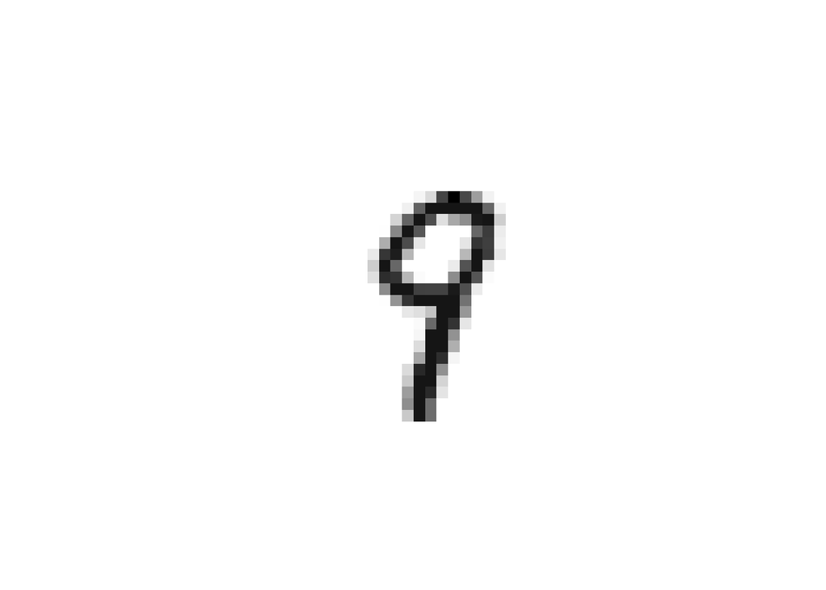

```r
# add channel dimension to input (required for convolution layers)
dim(mnist$train$x) <- c(dim(mnist$train$x), 1)
dim(mnist$test$x)  <- c(dim(mnist$test$x), 1)

plot_img(mnist$train$x[314,,,])
```

#### 3.1.11: Creating a *Convolutional* Neural Network

```r
cnn <-
  ## state what dimensions the input has: in our case, 28 x 28 pixels
  ## in greyscale, therefore 1
  keras_model_sequential(input_shape = c(28, 28, 1)) %>%
  ## Add a convolutional layer that divides the dataset into 6 filters
  ## and kernel size of a 5 by 5 matrix
  layer_conv_2d(filters = 6, kernel_size = c(5, 5)) %>%
  ## This is followed by a pooling layer, which gets the max variance value
  ## for every separate 4 by 4 matrix in order to reduce the dimensionality
  layer_max_pooling_2d(pool_size = c(4, 4)) %>%
  ## Then, we flatten the pooled matrix into a single vector
  layer_flatten() %>%
  ## We add a dense NN layer with 32 units with relu as activation function
  layer_dense(units = 32, activation = "relu") %>%
  ## and finally we define the output layer with softmax activation
  ## as we are working with categorical data
  layer_dense(10, activation = "softmax")

## And just like the previous models, we use the same compile arguments
cnn %>%
  compile(
    loss = "sparse_categorical_crossentropy",
    optimizer = "adam",
    metrics = c("accuracy")
  )
```

#### 3.1.12: Running the CNN for 10 epochs on the training data and looking at its performance

```r
cnn %>% fit(x = mnist$train$x, y = mnist$train$y, epochs = 10,
            validation_split = 0.2, verbose = 1)
```

We find that the model has an accuracy of .984 on the training set, and a validation accuracy of .979. This is somewhat higher (probably not significantly) than the previous models… So now let’s try to improve it!

#### 3.1.13: Creating our own CNN with improved validation accuracy

```r
set.seed(1248)
improv_cnn <-
  keras_model_sequential(input_shape = c(28, 28, 1)) %>%
  layer_conv_2d(filters = 4, kernel_size = c(3, 3)) %>%
  layer_max_pooling_2d(pool_size = c(2, 2)) %>%
  layer_conv_2d(filters = 8, kernel_size = c(3, 3)) %>%
  layer_max_pooling_2d(pool_size = c(2, 2)) %>%
  layer_flatten() %>%
  layer_dropout(rate = .1) %>%
  layer_dense(units = 64, activation = "relu") %>%
  layer_dropout(rate = .5) %>%
  layer_dense(10, activation = "softmax")

improv_cnn %>%
  compile(
    loss = "sparse_categorical_crossentropy",
    optimizer = "adam",
    metrics = c("accuracy")
  )

improv_cnn %>% fit(x = mnist$train$x, y = mnist$train$y, epochs = 10,
            validation_split = 0.2, verbose = 1)
```